# PA1_template

Narges Shah

April 17, 2016

# Reproducible Research: Peer Assessment 1

### Loading and preprocessing the data

```r
library(ggplot2)
library(scales)
setwd("~/Desktop/Data Science/Reproducible Research/RepData_PeerAssessment1")
if(!file.exists('activity.csv'))
  unzip('activity.zip')

data <- read.csv('activity.csv')
```

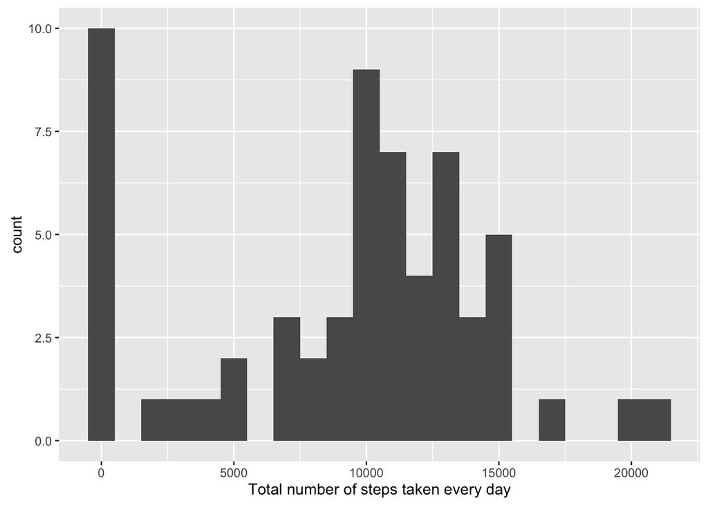

```r
totalSteps <- tapply(data$steps, data$date, FUN=sum, na.rm=TRUE)
qplot(totalSteps, binwidth = 1000, xlab="Total number of steps taken every day")
```

```r
meanSteps <- mean(totalSteps, na.rm = TRUE)
medianSteps <- median(totalSteps, na.rm = TRUE)
```

### What is the average daily activity pattern?

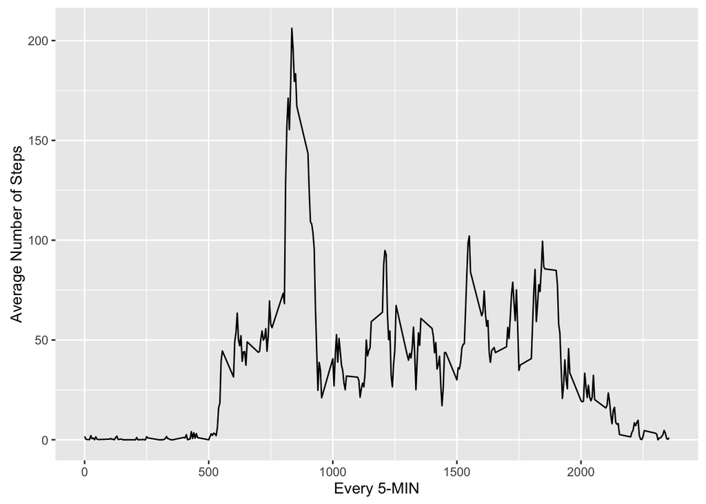

```r
averageSteps <- aggregate(x=list(steps = data$steps), by = list(interval = data$interval), FUN = mean, na.rm = TRUE)
ggplot(data = averageSteps, aes(x = interval, y = steps)) +
                                                  geom_line() +
                                                  xlab("Every 5-MIN") +
                                                  ylab("Average Number of Steps")
```

Which 5-minute interval, on average across all the days in the dataset, contains the maximum number of steps?

```r
averageSteps[which.max(averageSteps$steps),]
```

```
##     interval    steps
## 104      835 206.1698
```

## Imputing missing values

There are many days/intervals with missing values (`NA`).

```r
missing <- is.na(data$steps)
# How many missing
table(missing)
```

```
## missing
## FALSE  TRUE
## 15264  2304
```

All of the missing values are filled in with mean value for their 5-minute interval.

```r
# Replace each missing value with the mean value of its 5-minute interval
newData <- data
newData <- transform(data, steps = ifelse(is.na(data$steps), averageSteps$steps[match(data$interval, averageSteps$interval)], data$steps))
```

Using this new data set, we draw histogram of the total number of steps taken each day and calculate the mean and median total number of steps:

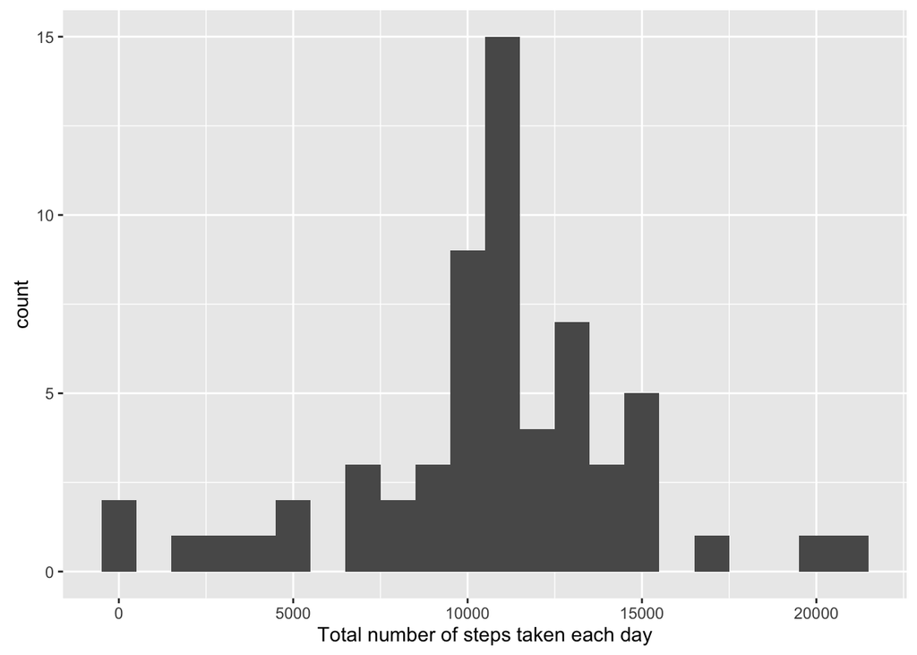

```r
totalSteps <- tapply(newData$steps, newData$date, FUN=sum)
qplot(totalSteps, binwidth=1000, xlab = "Total number of steps taken each day")
```

```r
mean(totalSteps)
```

```
## [1] 10766.19
```

```r
median(totalSteps)
```

```
## [1] 10766.19
```

## Are there differences in activity patterns between weekdays and weekends?

We should first calculate the weekday for each date and then decide if it’s a weekday or weekend using weekdayFactor function:

```r
weekdayFactor <- function(date) {
  day <- weekdays(date)
  if (day %in% c("Monday", "Tuesday", "Wednesday", "Thursday", "Friday"))
    return("weekday")
  else if (day %in% c("Saturday", "Sunday"))
    return("weekend")
  else
    stop("invalid date")
}
newData$date <- as.Date(newData$date)
newData$day <- sapply(newData$date, FUN = weekdayFactor)
```

For comparison we plot the number of steps taken in weekdays and weekends separately:

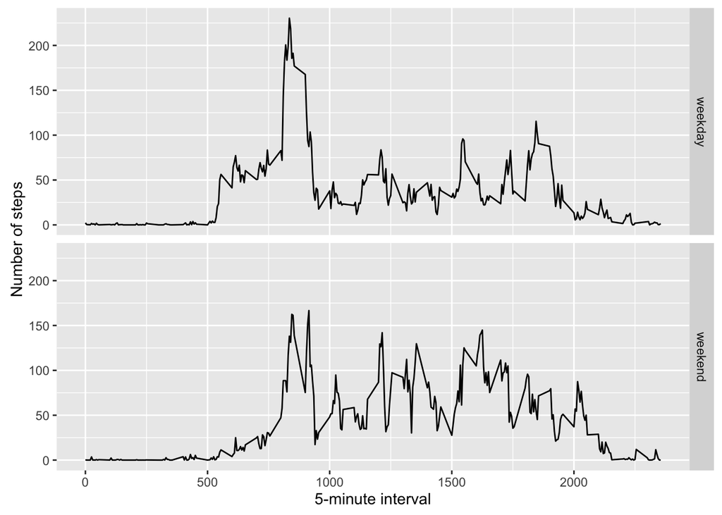

```r
averageSteps <- aggregate(steps ~ interval + day, data=newData, mean)
ggplot(averageSteps, aes(interval, steps)) + geom_line() + facet_grid(day ~ .) +
  xlab("5-minute interval") + ylab("Number of steps")
```